# Optical Illusions

Inspired by Nifty Assignment by Faan Tone Liu

Author

Jed Rembold

Published

July 19, 2024

# Introduction

The creation and discussion around optical illusions is generally agreed to date back to ancient Greece, where they were utilized in architecture and art. Since then, our understanding and science of what makes them work has continued to evolve. These days, it is easy to view whole archives of optical illusions, catalogized into such groupings as physical, physiological, and cognitive illusions. In this project your goal will be to recreate several of these illusions using the PGL library. Along the way, you will be tasked with writing and using functions to accomplish your artistic ends.

You can follow the below link to accept the assignment and get the starting templates.

[Accept Project](https://classroom.github.com/a/ucjxcGun)

# Functions

In each of the following parts (for each created illusion), you must define and utilize at least one function to help create your image. This function must take and use 1 or more parameters. It can return something, but it does not need to (often it is useful within the function to just create and add shapes directly to the canvas). Ensure that your functions have meaningful names and that you call them at least once (and ideally more) in your code!

# Illusion 1

To start off, we will recreate an optical illusion that mostly relies on a loop (or multiple loops) to achieve the target image. From the gallery of images below, choose ONE that you will recreate. Remember that you have access to very basic shapes so far within PGL, but all of these can be recreated with just those basic shapes.

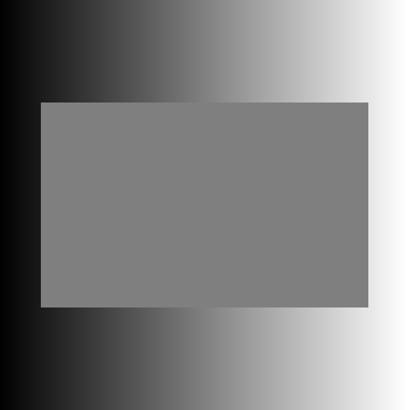

**The Gradient Illusion**: The background here is drawn with a gradient of gray colors, but the rectangle in the middle has only a single mid-intensity gray!

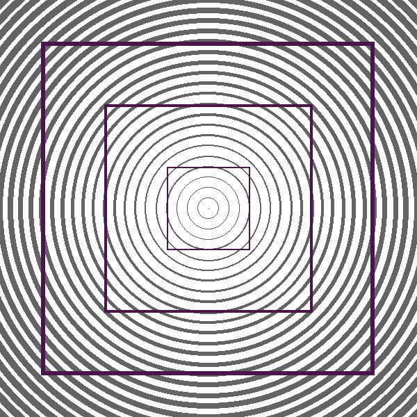

**Curving Squares**: Here the three purplish shapers really are squares, and they are not curved at all.

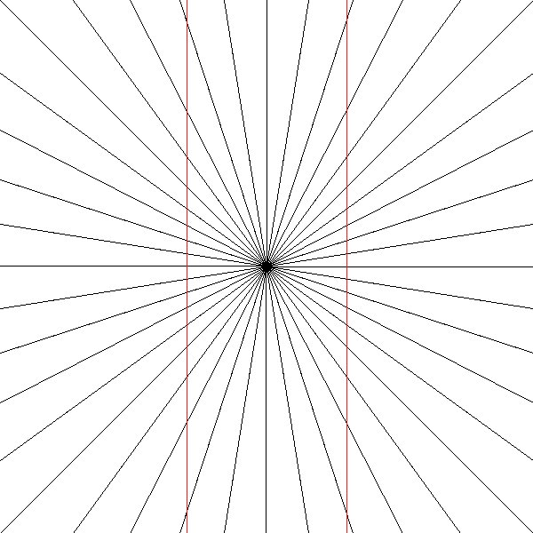

**Hering’s Illusion**: The red lines are not curved, just straight parallel lines. The radiating lines from the center are spaced with a constant angle between them.

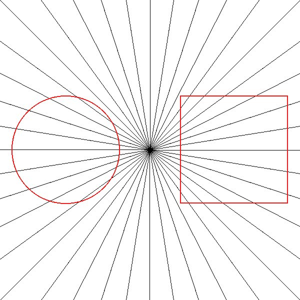

**Eisenstein’s Illusion**: The red shapes are a true circle and square, but appear distorted by the radiating lines. The radiating lines are spaced with a constant angle between them.

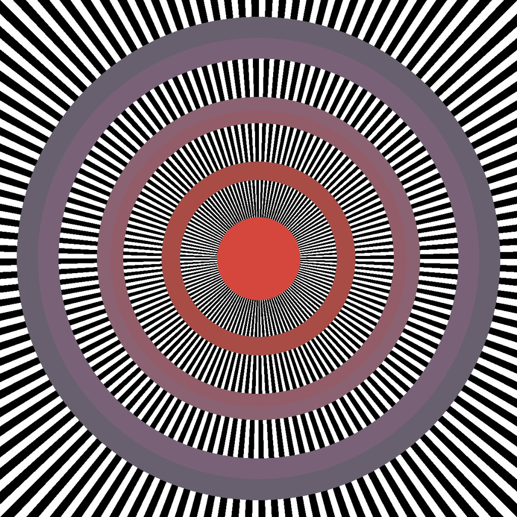

**Leviant Enigma**: Most people see illusory motion or flow within the purple rings. The radiating lines are spaced with a constant angle.

*Do not forget to define and use at least one function in the process of recreating your chosen image!*

Once you have recreated the original image as best as you are able, modify the image in some way to make your version distinct (change the colors, the number of lines, the thickness of lines, etc.). Comment on whether you think your changes improved, diminished, or kept the quality of the illusion the same.

**Tips**

Depending on your chosen image, here are a few tips you might find useful:

- PGL can not inherently create gradients. Instead, you need to draw many skinny rectangles of the correct color to achieve a similar effect. You can import the `generate_gradient` function from the `colortools` package provided to create a sequence of colors which you could then loop over.
- You can set the line width of any `GObject` with `obj.set_line_width(desired_width)`, where desired width defaults to 1.
- To draw the rays at constant angle intervals, some trigonometry would be necessary. You can import the `sin` and `cos` functions from the math library, as well as the `radians` function to convert degrees to radians as necessary for the trig functions.
- To draw a line that gets progressively wider, you need to break it up into smaller line segments and increase the width of each manually (or through a loop)

# Illusion 2

In this second set of illusions, you will need to rely not just on a single loop, but likely on *nested* loops to achieve the desired output. From the new list of images below, choose again a SINGLE image that you will try to recreate.

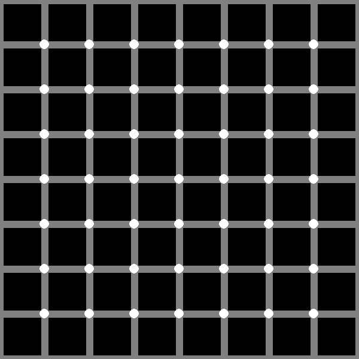

**Hermann Scintillating Grid**: The black dots that seem to appear in the middle of the while circles are illusory.

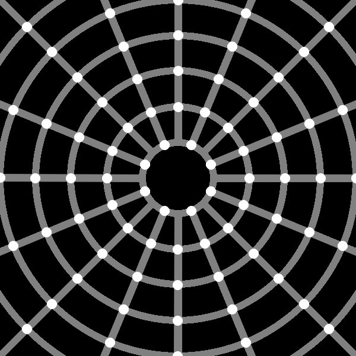

**Hermann Scintillating Web**: Again, the black dots that seem to appear in the white circles are illusory.

[figure not shown]

**Cafe Wall Illusion**: The gray lines are actually straight and parallel.

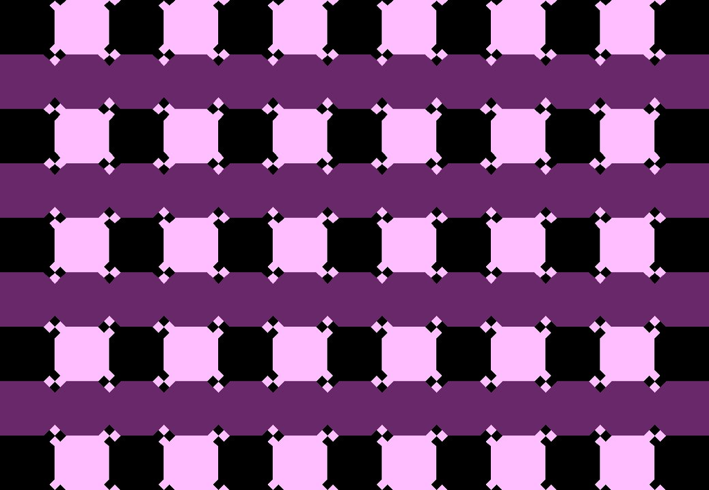

**Skye Blue Cafe Wall**: This is a simplified version of the [stunning illusion](https://illusionoftheyear.com/2017/10/skye-blue-cafe-wall-illusion/) created by Victoria Skye, which won the 2017 Illusion of the Year. The purple stripes are actually parallel.

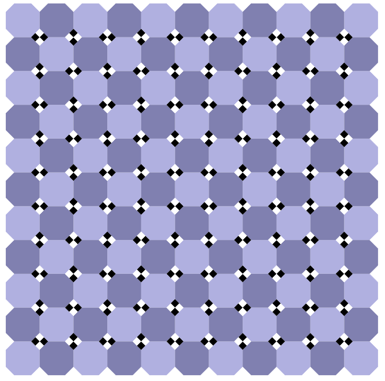

**Twisted Checkerboard**: The checkerboard in the background is formed from normal squares, despite their warped appearance.

*Again, do not forget to define and use at least one function in the process of recreating your chosen image!*

Once you have recreated the original image as best as you are able, modify the image in some way to make your version distinct (change the colors, the number of lines, the thickness of lines, etc.). Comment on whether you think your changes improved, diminished, or kept the quality of the illusion the same.

# Illusion 3

For this third illusion, everything is up to you! Choose your favorite optical illusion and attempt to recreate it as faithfully as possible within PGL. This can include optical illusions with motion if you want to wait until animation is covered next Wednesday! Keep in mind here that you only have access to pretty simple geometric shapes, so some illusions might be prohibitively difficult.

[video not shown]

Make sure you **still define and use a function** while recreating your image/animation, and alter some aspect of the illusion to make it your own.